# Tutorial for `jafar`

This tutorial provides an introduction to the $\texttt{R}$ package $\texttt{jafar}$, which implements the methodologies described in [Anceschi et al. (2025)](https://arxiv.org/abs/2406.00778). The package implements two supervised Bayesian factor modeling approaches for multi-view data integration:

- **Joint Factor Regression ($\texttt{JFR}$):** a baseline model that captures the combined variation across multiple data views using a single set of latent factors.
- **Joint Additive Factor Regression ($\texttt{JAFAR}$):** a more refined model that explicitly decomposes variation into shared and view-specific components.

Isolating variation unique to each data modality – whether genuine signal or measurement artifact – can be particularly advantageous in high-dimensional settings, increasing interpretability and improving scalability. $\texttt{JAFAR}$ ensures correct separation of the additive component by placing zero prior mass on configurations with ill-posed allocation of specific factors into the shared component.

Both models leverage extensions of the $\texttt{CUSP}$ prior [(Legramanti et al., 2020)](http://academic.oup.com/biomet/article/107/3/745/5847840), learning adaptively the number of factors in a fully Bayesian way. The package implements independent $\texttt{CUSP}$ priors ($\texttt{I-CUSP}$) for $\texttt{JFR}$ and dependent $\texttt{CUSP}$ priors ($\texttt{D-CUSP}$) for $\texttt{JAFAR}$.

In this tutorial, we focus on $\texttt{JAFAR}$ for ease of exposition. Using $\texttt{JFR}$ is completely analogous, simply replacing the function $\texttt{gibbs_jafar}$ with $\texttt{gibbs_jfr}$.

# Initial Imports

We begin by loading the required packages, including the R package $\texttt{jafar}$ that we developed.

```r
rm(list = ls())
library(jafar)
library(rstudioapi)
library(knitr)
library(ggplot2)
```

# Output Path

Set the working directory where to save the results. Modify $\texttt{output_dir}$ if you want to save results elsewhere.

```r
output_dir = file.path(dirname(getSourceEditorContext()$path), 'results')
dir.create(output_dir, showWarnings = FALSE)
```

# Data Import

The input data $\texttt{X_m}$ should be structured as a list of length $\texttt{M}$, where:

- $\texttt{M}$ is the number of views:
- $\texttt{n}$ is the number of samples
- $\texttt{p_m}$ is a vector of $\texttt{M}$ integers, where $\texttt{p_m[m]}$ is the number of features in view $\texttt{m}$.
- The m-th element of $\texttt{X_m}$ is an $\texttt{n x p_m[m]}$ matrix.

The response variable $\texttt{y}$ is a vector of length $\texttt{n}$. Test data must follow the same structure as the training data.

```r
data("Data", package = "jafar")
```

```r
M <- length(Data$X_m)
p_m <- sapply(Data$X_m,ncol)
n <- nrow(Data$X_m[[1]])
nTest <- nrow(Data$X_m_test[[1]])

summary_df <- rbind(data.frame(Element="Train Samples", Dimension=n),
                    data.frame(Element="Test Samples", Dimension=nTest),
                    data.frame(Element=paste0("View ",1:M), Dimension=p_m))
knitr::kable(summary_df, caption="Dimensionality Summary")
```

Dimensionality Summary

| Element | Dimension |
| --- | --- |
| Train Samples | 200 |
| Test Samples | 200 |
| View 1 | 100 |
| View 2 | 200 |
| View 3 | 300 |

# Data Pre-processing

$\texttt{JAFAR}$ leverages the $\texttt{CUSP}$ construction in the priors for the loading matrices. To follow recommended practice for applying $\texttt{CUSP}$, we standardize all features and responses to zero mean and unit variance. The package allows further pre-processing of the multi-view features via the cdf transform (use only if the data deviate from Gaussianity). For continuous $\texttt{X_m}$, this coincides with running a Copula factor model.

```r
preprocessed_X <- preprocess_X(Data$X_m,X_m_test=Data$X_m_test,copula=F)
X_m <- preprocessed_X$X_m
X_m_test <- preprocessed_X$X_m_test

preprocessed_y <- preprocess_y(Data$yTrain,yTest=Data$yTest)

y <- preprocessed_y$yTrain
yTest <- preprocessed_y$yTest
```

For better visualization, features in each view can be reordered by hierarchical clustering

```r
reordered_X <- reorder_features(Data$X_m,X_m_test=Data$X_m_test)
X_m <- reordered_X$X_m
X_m_test <- reordered_X$X_m_test
```

# MCMC Hyperparameters

$\texttt{jafar}$ requires setting different parameters to be used in the samplers. These include MCMC total number of samples, burn-in, thinning. The underlying $\texttt{CUSP}$ structures require conservative upper bounds on the number of factors.

- For $\texttt{jfr}$, $\texttt{K0}$ is the upper bound to the total number of factors.
  - If unspecified, $\texttt{K0}$ is set to $\text{floor}(3\cdot\log(\text{sum}(p_m)))$.
- For $\texttt{jafar}$, $\texttt{K0}$ is the upper bound to the number of shared factors, while $\texttt{K0_m}$ is a vector of length $\texttt{M}$ giving the upper bounds to the number of view-specific factors in each view.
  - If unspecified, $\texttt{K0}$ is set to $\text{floor}(3\cdot\log(\text{max}(p_m)))$
  - If unspecified, $\texttt{K0_m[m]}$ is set to $\text{floor}(3\cdot\log(p_m[m]))$.

The prior entails additional hyperparameters, detailed in the documentation of the function $\texttt{set_hyperparameters}$. They can be specified via the input list $\texttt{hyperparams}$, which we use to set the random seed. Here, the remaining hyperparameters are set to their default values, which are broadly applicable and work well across a variety of scenarios. We refer to the main manuscript for further guidance and intuition on their roles.

```r
tMCMC = 10000
tBurnIn = 5000
tThin = 10

mcmc_seed=1234

K0 = 25
K0_m = rep(20,M)
```

# 1. Unsupervised $\texttt{JAFAR}$

We first run $\texttt{JAFAR}$ in an unsupervised setting (simply by not including the response in the input). This corresponds to assuming a joint additive factor model with shared and specific components
$$X_{m i} =
\mu_m+ \Lambda_m \eta_i + \Gamma_m \phi_{m i} + \epsilon_{m i}$$
for each $i=1,\dots,n$ and $m=1,\dots,M$. Here:

- $X_{m i} \in \Re^{p_m}$
- $\mu_m \in \Re^{p_m}$
- $\Lambda_m \in \Re^{p_m \times K}$
- $\eta_i \in \Re^{K}$
- $\Gamma_m \in \Re^{p_m \times K_m}$
- $\phi_{m i} \in \Re^{K_m}$
- $\epsilon_{m i} \sim N_{K_m}(0,\Sigma_m)$
- $\Sigma_m = \text{diag}(\{\sigma_{mj}^2\}_{j=1}^{p_m}$
- $K$ is the number of shared factors
- $\{K_m\}_{m=1}^M$ are the number of specific factors

```r
mcmc_unsupervised <- gibbs_jafar(X_m, K0=K0, K0_m=K0_m,
                             tMCMC=tMCMC, tBurnIn=tBurnIn, tThin=tThin,
                             hyperparams = list(seed = mcmc_seed))
```

```
## [1] "Running un-supervised jafar under d-cusp prior"
##           [  0%] K=25 K1=20 K2=20 K3=20
##           [ 10%] K=14 K1=08 K2=10 K3=09
##           [ 20%] K=13 K1=09 K2=11 K3=10
##           [ 30%] K=14 K1=08 K2=10 K3=09
##           [ 40%] K=13 K1=09 K2=11 K3=10
##           [ 50%] K=14 K1=08 K2=10 K3=09
##           [ 60%] K=14 K1=08 K2=10 K3=09
##           [ 70%] K=14 K1=08 K2=10 K3=09
##           [ 80%] K=14 K1=08 K2=10 K3=09
##           [ 90%] K=14 K1=08 K2=10 K3=09
##           [100%] K=14 K1=08 K2=10 K3=09
```

The package offers different visualization functions to assess its performance. We first focus on number of factors and induced covariance.

## Number of Factors

$K$ and $\{K_m\}_{m=1}^M$ are learned adaptively as part of the inferential procedure. Inspecting the evolution of the inferred ranks can help understand if the provided upper bounds were large enough. This can be done via built-in plotting function in the package. The resulting graphics are always saved in pdf or png format, at the specified path.

```r
plot_n_factors(mcmc_unsupervised,out_path=output_dir)
```

```r
knitr::include_graphics(file.path(output_dir,'n_factors_shared.pdf'))
```

[figure not shown]

```r
knitr::include_graphics(file.path(output_dir,'n_factor_specific.pdf'))
```

[figure not shown]

## Correlations Matrices

The Gibbs sampler always report the posterior means of the with-in view covariance matrices
$$\Lambda_m\Lambda_m^T \!\!\,\, + \Gamma_m\Gamma_m^T + \Sigma_m \!\!\,\,$$

Their difference from the empirical ones can help assess how well the decomposition is performing. Built-in functions include visual representation facilitating this comparison, focusing on the associated correlation matrices.

```r
plot_correlations(mcmc_unsupervised, X_m, out_path=output_dir)
```

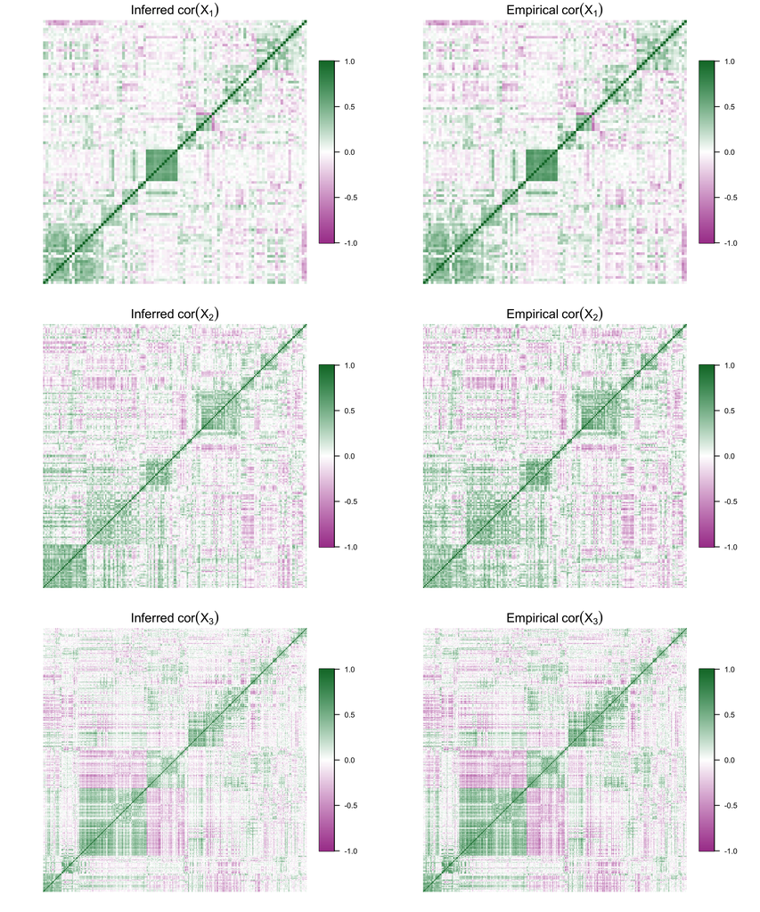

```r
knitr::include_graphics(file.path(output_dir,'correlations.png'))
```

# 2. Supervised $\texttt{JAFAR}$ - Continous Response

Secondly, we fit the supervised version of $\texttt{JAFAR}$, now including a response $y_i \in Re$. This entails extending the model above as
$$X_{m i} = \mu_m+
\Lambda_m \eta_i + \Gamma_m \phi_{m i} + \epsilon_{m i} \\
\quad\;\, y_{ i} = \mu_y + \theta^\top \eta_i +
\textstyle{\sum_{m}}\theta_m^\top \phi_{m i} + e_{ i} \\$$

where - $\mu_y \in \Re$ - $\theta \in \Re^{K}$ - $\theta_m \in \Re^{K_m} \quad \forall \; m=1,\dots,M$ - $e_{ i} \sim N(0,\sigma_y^2)$

```r
mcmc_supervised <- gibbs_jafar(X_m, y=y, K0=K0, K0_m=K0_m,
                             tMCMC=tMCMC, tBurnIn=tBurnIn, tThin=tThin,
                             hyperparams = list(seed = mcmc_seed))
```

```
## [1] "Running supervised jafar under d-cusp prior"
##           [  0%] K=25 K1=20 K2=20 K3=20
##           [ 10%] K=16 K1=08 K2=10 K3=10
##           [ 20%] K=15 K1=07 K2=09 K3=09
##           [ 30%] K=15 K1=07 K2=09 K3=09
##           [ 40%] K=16 K1=06 K2=10 K3=10
##           [ 50%] K=16 K1=08 K2=10 K3=10
##           [ 60%] K=16 K1=08 K2=10 K3=10
##           [ 70%] K=16 K1=08 K2=10 K3=10
##           [ 80%] K=16 K1=08 K2=10 K3=10
##           [ 90%] K=16 K1=08 K2=10 K3=10
##           [100%] K=16 K1=08 K2=10 K3=10
```

## Response Predicitions

We can then compute response predictions and assess predictive performance. Expected values and other distributional properties of $y_i \mid \{X_{m i}\}_m$ can be easily obtained leveraging the latent representation
$$\mathbb{E}[\,y_i \mid \{X_{m i}\}_m \,]
= \mathbb{E}\big[\, \mathbb{E}[\,y_i \mid \eta_i, \{\phi_{m i}\}_m \,]
\mid \{X_{m i}\}_m \big]$$
This holds both for in-sample and out-of-sample observations.

```r
y_pred <- predict_y(X_m,mcmc_supervised)
```

```
## [1] " - Computing Response Predictions - "
## [1] "         [  0%]"
## [1] "         [ 10%]"
## [1] "         [ 20%]"
## [1] "         [ 30%]"
## [1] "         [ 40%]"
## [1] "         [ 50%]"
## [1] "         [ 60%]"
## [1] "         [ 70%]"
## [1] "         [ 80%]"
## [1] "         [ 90%]"
## [1] "         [100%]"
```

Built-in functions allow to visualize mean predicted values and $90\%$ credible intervals against the truth.

```r
plot_predictions(y_pred,y,mcmc_supervised,out_path=output_dir)
```

```r
knitr::include_graphics(file.path(output_dir,'predictions.pdf'))
```

[figure not shown]

## Postprocessing Against Rotational Ambiguity

Interpreting the latent factors requires first solving rotational ambiguity, columns switching and sign switching. Specifically, for any set of orthogonal matrices $R$ and $R_m$ such that $R R^\top =I_K$ and $R_m R_m^\top =I_{K_m}$, simultaneously modifying loading matrices and latent factors as
$$\widetilde{\Lambda}_m = {\Lambda}_m R \qquad
\widetilde{\Gamma}_m = {\Gamma}_m R_m \\
\;\;\widetilde{\theta} = {\theta} R \qquad \quad
\widetilde{\theta}_m = {\theta}_m R_m \\
\;\, \widetilde{\eta}_i = R^\top \eta_i \qquad
\widetilde{\phi}_m = R_m^\top {\phi}_m$$
provide an equivalent representation.

Posterior samples must thus be aligned in order to compute meaningful Monte Carlo averages of latent variables. $\texttt{jafar}$ implements an extension of $\texttt{MatchAlign}$ [(Poworoznek et al., 2025)](https://projecteuclid.org/journals/bayesian-analysis/advance-publication/Efficiently-Resolving-Rotational-Ambiguity-in-Bayesian-Matrix-Sampling-with-Matching/10.1214/25-BA1544.full) to account for the multi-view structure in the shared component of the model. The specific components can be aligned with regular $\texttt{MatchAlign}$. All such post-processing routines are implemented jointly in the function $\texttt{multiviewMatchAlign}$.

```r
mcmc_supervised <- multiviewMatchAlign(mcmc_supervised)
```

```
## [1] "Rotating Shared Component"
## [1] "Finding Optimal Rotations"
## [1] "         [  0%]"
## [1] "         [ 10%]"
## [1] "         [ 20%]"
## [1] "         [ 30%]"
## [1] "         [ 40%]"
## [1] "         [ 50%]"
## [1] "         [ 60%]"
## [1] "         [ 70%]"
## [1] "         [ 80%]"
## [1] "         [ 90%]"
## [1] "         [100%]"
## [1] "Rotating Variables"
## [1] "Finding Pivot"
```

[output cut: 53 more lines]

Built-in function allows to visualize the resulting loading matrices, facilitating interpretation of the latent directions of variation.

```r
plot_loadings(mcmc_supervised,out_path=output_dir)
```

```r
knitr::include_graphics(file.path(output_dir,'shared_loadings.pdf'))
```

[figure not shown]

```r
knitr::include_graphics(file.path(output_dir,'specific_loadings.pdf'))
```

[figure not shown]

# 3. Supervised $\texttt{JAFAR}$ - Binary Response

Finally, we show how to fit $\texttt{JAFAR}$ with binary responses. We first artificially create binary outcomes for the tutorial data.

```r
# convert y to binary
cens_thr <- quantile(Data$yTrain,0.65)
y01 <- 1*(Data$yTrain > cens_thr)
yTest01  <- 1*(Data$yTest > cens_thr)
```

In such a case, $\texttt{JAFAR}$ assumes a probit link to model the response part.
$$y_i \sim Bernoulli \big( \Phi(\mu_y+\theta^\top
\eta_i + \textstyle{\sum_{m}}\theta_m^\top \phi_{m i}) \big)$$
where $\Phi(\cdot)$ is the cumulative distribution function of the standard normal.

The binary-response version is selected by specifying $\texttt{yBinary=TRUE}$ in the input of the Gibbs sampler.

```r
mcmc_binary <- gibbs_jafar(X_m, y=y01, yBinary=TRUE, K0=K0, K0_m=K0_m,
                             tMCMC=tMCMC, tBurnIn=tBurnIn, tThin=tThin,
                             hyperparams = list(seed = mcmc_seed))
```

```
## [1] "Running supervised jafar under d-cusp prior"
##           [  0%] K=25 K1=20 K2=20 K3=20
##           [ 10%] K=15 K1=09 K2=09 K3=09
##           [ 20%] K=15 K1=09 K2=09 K3=09
##           [ 30%] K=14 K1=08 K2=10 K3=10
##           [ 40%] K=14 K1=08 K2=10 K3=10
##           [ 50%] K=14 K1=08 K2=10 K3=10
##           [ 60%] K=14 K1=08 K2=10 K3=10
##           [ 70%] K=14 K1=08 K2=10 K3=10
##           [ 80%] K=14 K1=08 K2=10 K3=10
##           [ 90%] K=14 K1=08 K2=10 K3=10
##           [100%] K=14 K1=08 K2=10 K3=10
```

## Response Predicitions

Once again, we can compute response predictions and visually assess the associated performance. Prediction samples now correspond to the linear predictors $\theta^\top \eta_i + \textstyle{\sum_{m}}\theta_m^\top \phi_{m i}$ under the probit formulation.

```r
y01_pred <- predict_y(X_m,mcmc_binary)
```

```
## [1] " - Computing Response Predictions - "
## [1] "         [  0%]"
## [1] "         [ 10%]"
## [1] "         [ 20%]"
## [1] "         [ 30%]"
## [1] "         [ 40%]"
## [1] "         [ 50%]"
## [1] "         [ 60%]"
## [1] "         [ 70%]"
## [1] "         [ 80%]"
## [1] "         [ 90%]"
## [1] "         [100%]"
```

As before, allows to visualize predicted values against the truth.

```r
plot_predictions(y01_pred,y01,mcmc_binary,out_path=output_dir,out_name='binary_predictions')
```

```r
knitr::include_graphics(file.path(output_dir,'binary_predictions.pdf'))
```

[figure not shown]

## Induced Coefficients

further allows to inspect predictive power across features and views by visualizing the induced regression coefficients $\{\beta_m \in \Re^{p_m}\}_m$ directly for $y_i \mid \{X_m\}_m$. This representation is obtained by marginalizing out all latent factors, so that $y_{ i} \sim N\big(\mu_y+\textstyle{\sum_{m}}\beta_m^\top X_{m i},\sigma_y^2 \big)$ for continuous responses and $y_i \sim Bernoulli \big( \Phi(\mu_y+\textstyle{\sum_{m}}\beta_m^\top X_{m i}) \big)$ for binary ones. Such regression coefficients are automatically returned when computing predictions via $\texttt{predict_y}$.

```r
plot_coefficients(y01_pred)
```

```r
knitr::include_graphics(file.path(output_dir,'coefficients.pdf'))
```

[figure not shown]